# Model of Human Activity Recognition

Soparkar A

March 22, 2015

## Executive Summary

Using devices such as Jawbone Up, Nike FuelBand, and Fitbit it is now possible to collect a large amount of data about personal activity relatively inexpensively. Using this data (obtained from http://groupware.les.inf.puc-rio.br/har project), data gathered from accelerometers placed on the belt, forearm, arm, and dumbell of six participants is analyzed here to predict how well they executed the exercisea in terms of the classification in the data.

## Libraries

To start with, here are the libraries which the code uses.

```r
library(caret)
library(kernlab)
library(randomForest)
library(corrplot)
library(RCurl)
library(parallel);
library(doParallel);
```

## Loading and cleaning the data

As seen here, two datasets - one for the training data and the other for test data - are loaded. We clean training dataset here. The same steps are applied later to testing dataset, before we actually use it. Many columns in the dataset contain NA values, which are removed. Columns with names and timestamps are also removed.

```r
# read the data
trdata <- getURL("https://d396qusza40orc.cloudfront.net/predmachlearn/pml-training.csv", ssl.verifypeer=0L, followlocation=1L)
training_data <- read.csv(text=trdata, na.strings= c("NA",""," "))
tsdata <- getURL("https://d396qusza40orc.cloudfront.net/predmachlearn/pml-testing.csv", ssl.verifypeer=0L, followlocation=1L)
testing_data <- read.csv(text=tsdata, na.strings= c("NA",""," "))

# remove columns with NAs
training_data_NAs <- apply(training_data, 2, function(x) {sum(is.na(x))})
training_data_clean <- training_data[,which(training_data_NAs == 0)]

# remove identifier columns such as names and timestamps
training_data_clean <- training_data_clean[8:length(training_data_clean)]
```

After cleanup, we now work with only 53 columns, out of original 160 columns.

## Separation of Trainig set

70% of training set is used for training our model. The rest 30% is set aside for cross-validation.

```r
# split the cleaned testing data into training and cross validation
inTrain <- createDataPartition(y = training_data_clean$classe, p = 0.7, list = FALSE)
training <- training_data_clean[inTrain, ]
cv <- training_data_clean[-inTrain, ]
```

## Creation of model

Here we use Random Forest model to train the given dataset. This is a good choice because random forests strike a good balance between accuracy and performance. With large number of trees, the generalization erro fro the forest converges. Lower correlation among trees also results in lower error rate. We start with creating a correlation plot to see the strength of relationship among variables. Left end (dark red) shows strongly negative relationships, while right end (dark blue) represents strongly positive relationships.

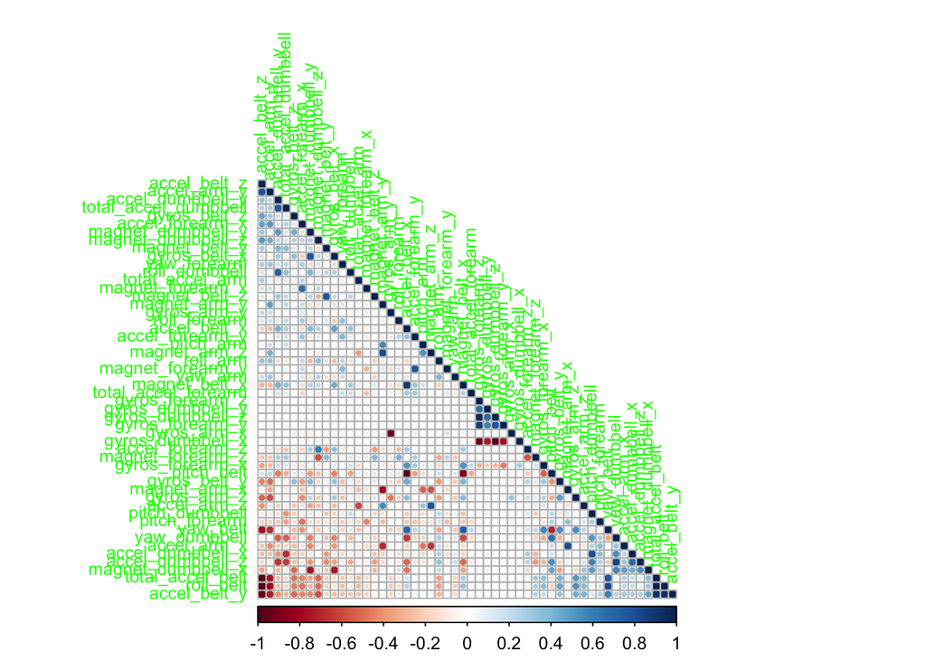

```r
# plot the correlation matrix
correlMatrix <- cor(training[, -length(training)])
corrplot(correlMatrix, order = "FPC", method = "circle", type = "lower", tl.cex = 0.8,  tl.col = rgb(0, 1, 0))
```

Using ‘classe’ variable as the outcome and all other variables as the predictors, we create the model.

```r
# fit the model to predict the classe using everything else as a predictor
registerDoParallel(clust <- makeForkCluster(detectCores()));
modelFit <- randomForest(classe ~ ., data = training)
stopCluster(clust);
modelFit
```

```
##
## Call:
##  randomForest(formula = classe ~ ., data = training)
##                Type of random forest: classification
##                      Number of trees: 500
## No. of variables tried at each split: 7
##
##         OOB estimate of  error rate: 0.57%
## Confusion matrix:
##      A    B    C    D    E class.error
## A 3901    3    1    0    1 0.001280082
## B   12 2641    5    0    0 0.006395786
## C    0   15 2379    2    0 0.007095159
## D    0    0   28 2222    2 0.013321492
## E    0    0    2    7 2516 0.003564356
```

## Cross Validation

```r
# cross-validate the model using the remaining 30% of trainig data
predictCrossVal <- predict(modelFit, cv)
confusionMatrix(cv$classe, predictCrossVal)
```

```
## Confusion Matrix and Statistics
##
##           Reference
## Prediction    A    B    C    D    E
##          A 1674    0    0    0    0
##          B    4 1134    1    0    0
##          C    0   15 1011    0    0
##          D    0    0    7  957    0
##          E    0    0    4    6 1072
##
## Overall Statistics
##
##                Accuracy : 0.9937
##                  95% CI : (0.9913, 0.9956)
##     No Information Rate : 0.2851
##     P-Value [Acc > NIR] : < 2.2e-16
##
##                   Kappa : 0.992
##  Mcnemar's Test P-Value : NA
##
## Statistics by Class:
##
##                      Class: A Class: B Class: C Class: D Class: E
## Sensitivity            0.9976   0.9869   0.9883   0.9938   1.0000
## Specificity            1.0000   0.9989   0.9969   0.9986   0.9979
## Pos Pred Value         1.0000   0.9956   0.9854   0.9927   0.9908
## Neg Pred Value         0.9991   0.9968   0.9975   0.9988   1.0000
## Prevalence             0.2851   0.1952   0.1738   0.1636   0.1822
## Detection Rate         0.2845   0.1927   0.1718   0.1626   0.1822
## Detection Prevalence   0.2845   0.1935   0.1743   0.1638   0.1839
## Balanced Accuracy      0.9988   0.9929   0.9926   0.9962   0.9990
```

## Prediction of Testing set

Now we procede to apply this model to the testing set. We first clean the testing dataset.

```r
# clean the final testing data in the same way
testing_data_NAs <- apply(testing_data, 2, function(x) {sum(is.na(x))})
testing_data_clean <- testing_data[,which(testing_data_NAs == 0)]
testing_data_clean <- testing_data_clean[8:length(testing_data_clean)]
```

And now we use the model to predict the testing set.

```r
# predict the classes of the test set
predictTest <- predict(modelFit, testing_data_clean)
predictTest
```

```
##  1  2  3  4  5  6  7  8  9 10 11 12 13 14 15 16 17 18 19 20
##  B  A  B  A  A  E  D  B  A  A  B  C  B  A  E  E  A  B  B  B
## Levels: A B C D E
```